# Practical Machine Learning Course Project

#### **12. Understanding and plotting the misclassified data points:**

The misclassified data points were plotted against the top two variables, to understand the reason for them being misclassified. The points were almost near the borders of the classes, and hence incorrectly misclassified.

```r
#12.1 Getting the right predictions
sub_testing_data$predRight <- pred_rf==sub_testing_data$classe
```

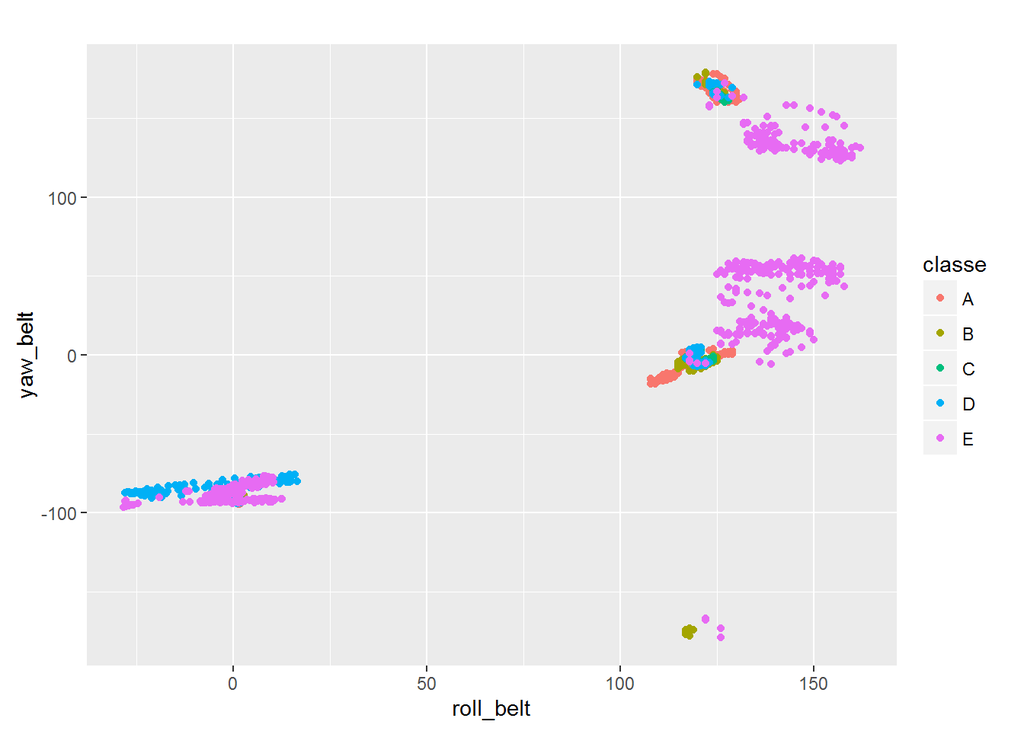

```r
#12.2 Identifying actual data points(classes) with respect to the above two features:
#Actual distribution of the classes
qplot(roll_belt,yaw_belt,colour=classe,data=sub_testing_data,main="")
```

The different classes have been represented by different colors. However, inorder to identify the misclassified points, the confusion matrix is plotted against the two top features.

Misclassified points:

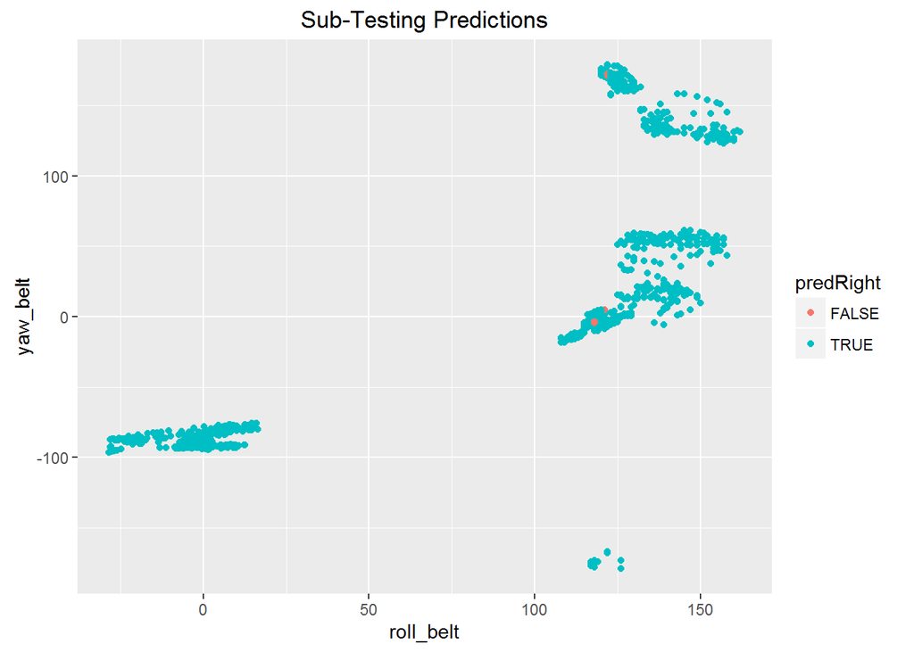

```r
#12.3 Identifying the mis-classified data points with respect to the above two features:
#Misclassified data-points
qplot(roll_belt,yaw_belt,colour=predRight,data=sub_testing_data,main="Sub-Testing Predictions")
```

```r
#Datapoints near the borders being misclassified
```

Hence, it is the data points near the boundaries of the classes, that have been mis classified. But more than 99% of the data points have been classified accurately.

#### **13. Predicting the test data set:**

The cross-validated, final random forest model is now applied on the test dataset to yield the final predictions. The model could classify the test set into the right classes.

```r
#13.1 Predicting the final test set
Final_Predict=predict(mod_rf,testing_data)
Final_Predict
```

```
##  [1] B A B A A E D B A A B C B A E E A B B B
## Levels: A B C D E
```